# 美国职业大联盟击球数据分析

## 获取数据

| playerID | Player ID code(球员ID) |
| --- | --- |
| yearID | Year(年份) |
| stint | player's stint(本赛季代表的第几支球队出场) |
| teamID | Team(球队) |
| lgID | League(联盟) |
| G | Games(上场次数) |
| AB | At Bats(打数) |
| R | Runs(得分) |
| H | Hits(安打) |
| 2B | Doubles（二垒安打） |
| 3B | Triples（三垒安打） |
| HR | Homeruns（本垒打） |
| RBI | Runs Batted In（打点） |
| SB | Stolen Bases（盗垒） |
| CS | Caught Stealing（盗垒失败） |
| BB | Base on Balls（保送） |
| SO | Strikeouts（三振） |
| IBB | Intentional walks（故意四坏球） |
| HBP | Hit by pitch（触身球） |
| SH | Sacrifice hits（牺牲触击） |
| SF | Sacrifice flies（高飞牺牲打） |
| GIDP | Grounded into double plays（双杀） |

## 提出问题

根据数据集的数据，提出如下问题：

1. 有哪些指标之间程有明显的正相关或负相关？
2. 各联盟之间击球手场均得分均值比较？
3. 击球手场均得分均值每年的变化趋势？
4. 赛季获奖球员和赛季未获奖球员的场均得分分布是否有明显差别？

## 清理数据

读取数据，并将数据加载到DataFrame数据结构中

```python
import numpy as np
import pandas as pd
import seaborn as sns
import matplotlib.pyplot as plt
%matplotlib inline
#读取击球统计数据集，并将数据载入DataFrame数据结构
Batting_df=pd.read_csv('Batting.csv')

#函数not_na_num可以计算一个Series中非空数据的数目
def not_na_num(df):
   return sum(df.notnull())

#将函数not_na_num应用到击球统计数据集Batting_df，计算每个统计项的数据数目
Batting_df.apply(not_na_num)
```

```
playerID    102816
yearID      102816
stint       102816
teamID      102816
lgID        102079
G           102816
AB          102816
R           102816
H           102816
2B          102816
3B          102816
HR          102816
RBI         102392
SB          101516
CS           79360
BB          102816
SO           94978
IBB          66251
HBP         100006
SH           96478
SF           66782
GIDP         76706
dtype: int64
```

可以看出，有些统计项数据有缺失，考虑到这个统计持续了好多年，猜测是因为早年未对这些值进行统计，为了不影响后续分析，用相应统计项的平均值填充缺失值

```python
#计算DataFrame每列、即每项统计数据的平均值，并用每项统计数据的平均值填充该统计项的缺失值
Batting_df.replace(np.nan,Batting_df.mean(),inplace=True)

#也可用如下函数进行处理
#Batting_df.fillna(Batting_df.mean(),inplace=True)
```

为每条记录添加场均得分数据项R_per_G

```python
#一名击球手某赛季的得分数'R'除以参赛场数'G'可以得到该击球手本赛季场均得分数
Batting_df['R_per_G']=Batting_df['R']/Batting_df['G']
```

## 分析数据

首先利用相关系数热力图计算并展示以下几项击打数据的相关系数

| AB | At Bats(打数) |
| --- | --- |
| R | Runs(得分) |
| H | Hits(安打) |
| 2B | Doubles（二垒安打） |
| 3B | Triples（三垒安打） |
| HR | Homeruns（本垒打） |
| RBI | Runs Batted In（打点） |
| SB | Stolen Bases（盗垒） |
| CS | Caught Stealing（盗垒失败） |
| BB | Base on Balls（保送） |
| SO | Strikeouts（三振） |
| IBB | Intentional walks（故意四坏球） |
| HBP | Hit by pitch（触身球） |
| SH | Sacrifice hits（牺牲触击） |
| SF | Sacrifice flies（高飞牺牲打） |
| GIDP | Grounded into double plays（双杀） |

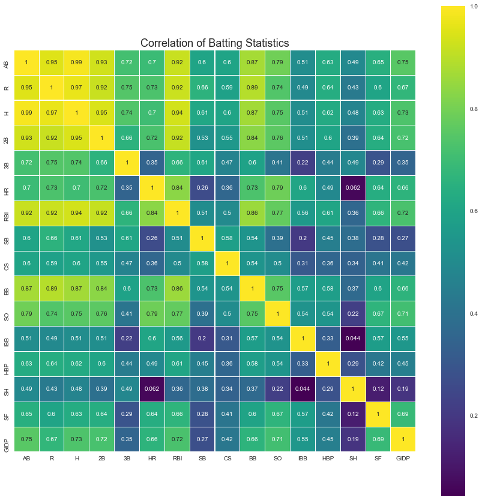

```python
#计算各打击数据间的相关性，结果为Batting_corr
Batting_corr=Batting_df[['AB','R','H','2B','3B','HR','RBI','SB','CS','BB','SO','IBB','HBP','SH','SF','GIDP']].corr()

plt.figure(figsize=(15,15))
plt.title('Correlation of Batting Statistics',size=18)

#使用热力图表示各打击数据的相关性，热力图图谱采用plt.cm.viridis
sns.heatmap(Batting_corr,linewidths=0.1,vmax=1.0, square=True, cmap=plt.cm.viridis,linecolor='white', annot=True)
```

然后计算各联盟击球手的平均场均得分并绘制成柱状图

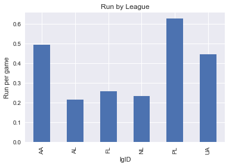

```python
#击球数据按照联盟进行分组，并计算每个联盟的击球手平均场均得分
R_per_League=Batting_df.groupby(['lgID'])['R_per_G'].mean()

#绘制条形图表示各联盟的击球手平均场均得分
plt.title('Run by League')
plt.xlabel('League')
plt.ylabel('Run per game')
R_per_League.plot(kind='bar')
```

**结论2：**由上面的柱状图可以看出，PL联盟每名击球手的场均得分最高,为0.63分，AL联盟最低，为0.21分。  
**分析中的限制**：每名运动员每赛季的参赛场次数据和得分数据都没有缺失，这个柱状图可以如实反映各联盟、击球手的平均场均得分

接下来计算每年的场均得分，并与年份绘制折线图。

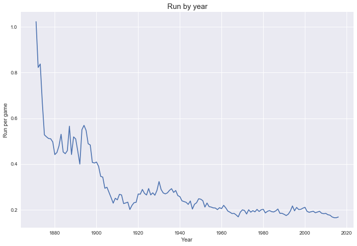

```python
#将击球统计数据按年份分组，并计算每组的击球手场均得分的平均值
R_per_year=Batting_df.groupby(['yearID'],as_index=False)['R_per_G'].mean()

#绘制击球手场均得分均值随年份变化的曲线图
plt.figure(figsize=(12,8))
plt.title('Run by year',size=15)
plt.xlabel('Year')
plt.ylabel('Run per game')
plt.plot(R_per_year['yearID'],R_per_year['R_per_G'])
```

**结论3：**  
从图中可以看出，随着时间的推移，击球手场均得分整体呈下降趋势。猜想可能的原因是，随着时间的推移，球队的技术越来越成熟，防守越来越严密，因而得分越来越困难。  
**分析中的限制**：只是通过图形简单判断了击球手场均得分均值随年份变化的趋势，没有计算击球手场均得分均值与年份的相关系数。此外，即使计算出击球手场均得分均值与时间在统计学上高度相关，也只能说明场均得分均值与时间有相关性，并不能证明因果性。

最后，比较赛季获奖和未获奖球员的场均得分分布。需要对数据做进一步处理。

因为有的球员单个赛季代表多个球队参赛而产生多条记录，需要对其进行合并处理，生成新的数据集，并重新计算该球员的赛季场均得分。

```python
#将击球统计数据集按选手和年份进行分组，合并选手和年份均相同的统计条目，形成新数据集Batting_drop_duplicated。
#同时，根据问题描述，新数据集只需要G（参赛场数）和R（得分）两个统计项。
Batting_drop_duplicated=Batting_df.groupby(['playerID','yearID'],as_index=False)[['G','R']].sum()

#在新的数据集中计算每个击球手某赛季场均得分数
Batting_drop_duplicated['R_per_G']=Batting_drop_duplicated['R']/Batting_drop_duplicated['G']
```

读取球员获奖情况数据集（AwardsPlayers.csv），并根据此数据集，为上一步生成的数据集增加一列数据项，即指定赛季运动员是否获奖Awarded

```python
#读取获奖数据集，并将数加载到DataFrame数据结构
AwardsPlayers_df=pd.read_csv('AwardsPlayers.csv')

#由于要计算一名运动员在某赛季是否获奖，即Batting_drop_duplicated统计条目中的yearID和playerID同时和AwardsPlayers_df条目中的相符
#需要先将Batting_drop_duplicated和AwardsPlayers_df数据集中的playerID和yearID两项合并，再利用isin函数计算指定赛季运动员是否获奖
Batting_drop_duplicated['player_year']=Batting_drop_duplicated['playerID'].astype(str)+Batting_drop_duplicated['yearID'].astype(str)
AwardsPlayers_df['player_year']=AwardsPlayers_df['playerID'].astype(str)+AwardsPlayers_df['yearID'].astype(str)
Batting_drop_duplicated['Awarded']=Batting_drop_duplicated['player_year'].isin(AwardsPlayers_df['player_year'])
```

计算赛季获奖和未获奖球员的场均得分均值，同时制作赛季获奖和未获奖球员的场均得分相对频率分布直方图，进行比较。

```python
#计算赛季获奖和未获奖球员的场均得分均值
Batting_drop_duplicated.groupby('Awarded')['R_per_G'].mean()
```

```
Awarded
False    0.22816
True     0.48169
Name: R_per_G, dtype: float64
```

```python
#分别找出球员赛季获奖和未获奖的统计项
Batting_Awarded=Batting_drop_duplicated[Batting_drop_duplicated['Awarded']==True]
Batting_unAwarded=Batting_drop_duplicated[Batting_drop_duplicated['Awarded']==False]
```

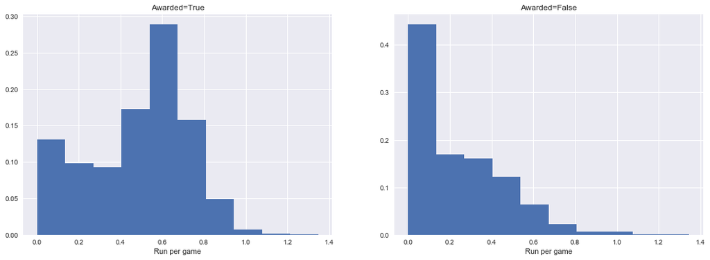

```python
#分别绘制赛季获奖和未获奖球员的场均得分的相对频率分布直方图
f=plt.figure(figsize=(18,6))
f.add_subplot(1,2,1)

#记录赛季获奖球员场均得分的相对频率分布直方图的区间划分bin，在制作赛季获奖球员场均得分的相对频率分布直方图时采用相同的区间划分
bin=plt.hist(Batting_Awarded['R_per_G'],weights=np.zeros_like(Batting_Awarded['R_per_G'])+1./ Batting_Awarded['R_per_G'].size)
plt.title('Awarded=True')
plt.xlabel('Run per game')
f.add_subplot(1,2,2)
plt.hist(Batting_unAwarded['R_per_G'],bins=bin[1],weights=np.zeros_like(Batting_unAwarded['R_per_G'])+1./ Batting_unAwarded['R_per_G'].size)
plt.title('Awarded=False')
plt.xlabel('Run per game')
```

**结论4：**从上面的结果可以看出，赛季获奖球员场均得分大于赛季未获奖球员，约为0.25。  
赛季获奖球员与赛季未获奖球员场均得分相对频数分布如上图所示，可以看出，赛季未获奖球员与赛季获奖球员场均得分分布差异明显。赛季获奖球员场均得分相对频数最大的区间约为[0.5,0.7)，而赛季未获奖球员场均得分相对频数最大的区间约为[0,0.1)。同时，与赛季获奖球员相比，赛季未获奖球员场均得分集中分布在场均得分更小的区间。  
**分析中的限制**：未进行统计检验，无法说明季获奖球员场均得分在统计学上是否显著大于赛季未获奖球员，影响结论显著性。同时，因为从相对频数分布直方图上可以看出，球员场均得分的相对频数并不近似于正态分布，无法用t检验进行统计检验，若要进行统计检验需要寻找其他统计检验方法。